# Missing data - babylab

M. Rolland

15/12/2020

To do:

- May want to merge with var coding doc

To discuss:

- OK to simple impute tobacco?
- What to do with missing T3 exposures?

# 1 Intro

# 2 Variables

## 2.1 Outcome

See `data_exploration.html` doc for final babylab data selection:

- **Group 1 - mean fixation duration**: `fix_dur_scene`, `fix_dur_face`
- **Group 2 - reaction time**: `reac_time_pursuit`
- **Group 3 - eye exploration**: `pct_eyes_face`
- **Group 4 - looking location**: `map_scene`, `map_face`
- **Group 5 - reaction to novelty**: `novelty_face`
- **Group 6 - attention quality**: `look_t_all_scene`, `look_t_all_face`

## 2.2 Exposure

As described in the pregnancy phenols & phthalates data `readme`, analyses will be carried out on the **filled-in and protocol variable corrected** phthalates. For this paper we will only look at the molar sums of compounds with the same parent compound and not the individual metabolites. So the final compounds used are:

```
##  [1] "ident"                "mo_MEP_i_cor_t2"      "mo_MEP_i_cor_t3"
##  [4] "mo_MnBP_i_cor_t2"     "mo_MnBP_i_cor_t3"     "mo_MiBP_i_cor_t2"
##  [7] "mo_MiBP_i_cor_t3"     "mo_MBzP_i_cor_t2"     "mo_MBzP_i_cor_t3"
## [10] "mo_ohMPHP_i_cor_t2"   "mo_ohMPHP_i_cor_t3"   "mo_DINCH_ms_i_cor_t2"
## [13] "mo_DINCH_ms_i_cor_t3" "mo_DEHP_ms_i_cor_t2"  "mo_DEHP_ms_i_cor_t3"
## [16] "mo_DiNP_ms_i_cor_t2"  "mo_DiNP_ms_i_cor_t3"
```

## 2.3 Model covariates

According to the DAG produced by C. Philippat and M. Rolland (`figs/DAG/dagitty-model_2020-11-27.jpg`) the final model covariates are:

- Ethnicity
- Exposure to other contaminant (smoking)
- Maternal depression
- Parental education
- Parity
- Maternal age

# 3 Entry datasets

## 3.1 Files

- `data/babylab_200218.dta`: Babylab eye tracker scores and age at experiment, provided by the babylab and produced by K. Supernant
- `data/phenols_phthalates_pregnancy_mr_2020-03-26_448.csv`: sample levels of phenols and phthalates measured during pregnancy for women from the sepages cohort, measured by the NIPH and produced by C. Philippat and M. Rolland (cf. readme)
- `data/bdd_grossesse_v4.dta`: Fourth version of the labs pregnancy data, where are the other model covariates come from, produced and documented by K. Supernant

## 3.2 Preprocessing

No pre processing applied to any of the datasets.

# 4 Outcome data

N outcome per age category:

| age_cat | fix_dur | look_t | map | novelty | pct_eyes | reac_t |
| --- | --- | --- | --- | --- | --- | --- |
| 5 | 39 | 39 | 39 | 39 | 39 | 39 |
| 12 | 66 | 66 | 66 | 66 | 66 | 64 |
| 24 | 150 | 150 | 150 | 150 | 150 | 145 |

39 observations at 5m, 66 at 12m and 150 at 24m. A few less for reaction time.

# 5 Missing data pattern

## 5.1 5 months

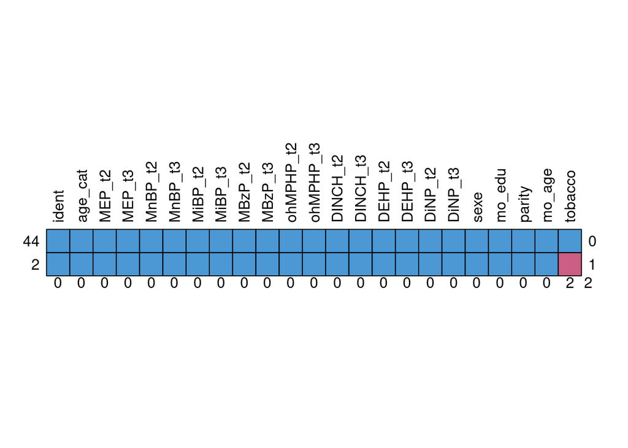

- 2 missing tobacco

## 5.2 12 months

```
##  /\     /\
## {  `---'  }
## {  O   O  }
## ==>  V <==  No need for mice. This data set is completely observed.
##  \  \|/  /
##   `-----'
```

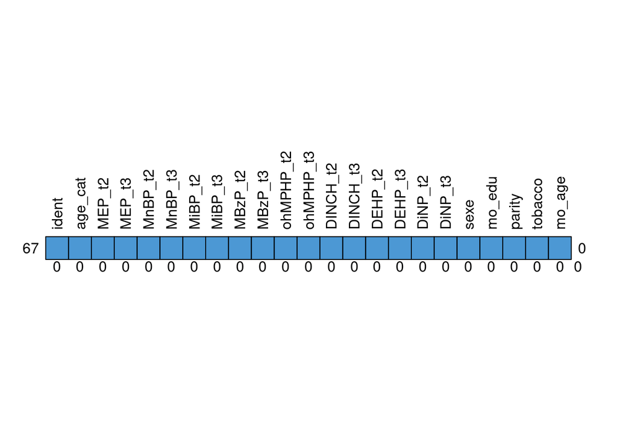

- No missing

## 5.3 24 months

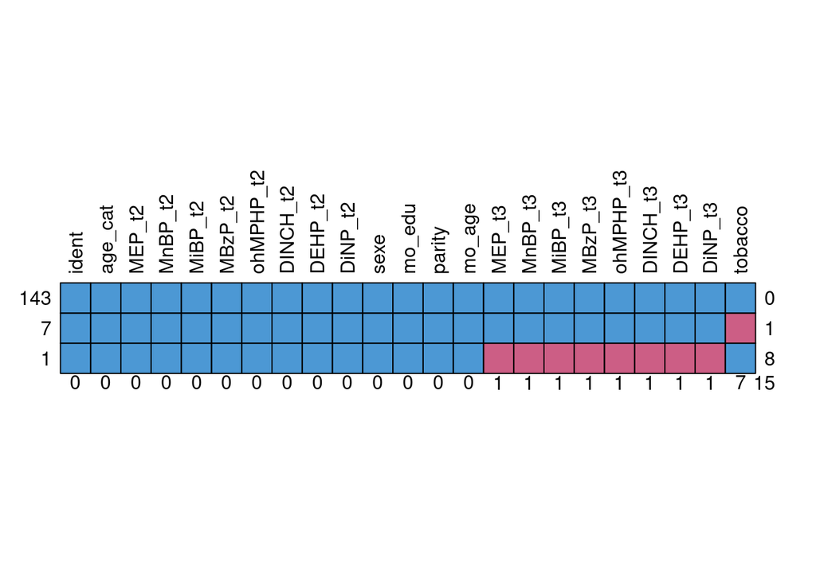

- 7 missing tobacco
- 1 missing exposure at T3

## 5.4 Conclusions

- Simple impute tobacco
- What about the missing T3 exposure?